# Heap

A **heap** is a *complete binary tree* that obeys the *heap order property*.

🤨

A **complete binary tree** is a binary tree (i.e. each node has at most two children) where every row but the last must be completely filled.

And the elements on the last row must be packed to the left.

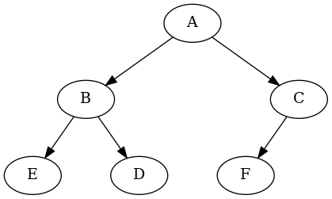

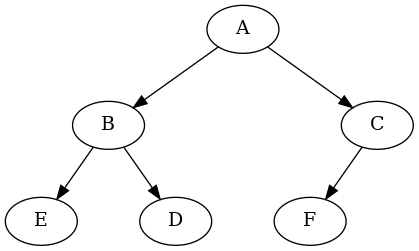

You can think of the "heavy" values sinking to the bottom of the tree.

## Inserting into a heap

- Add an item to the next open slot
- Percolate up until the value is in the correct location

To *percolate up*:

- Compare the current value to the value of the parent node
- If the parent value is greater, swap

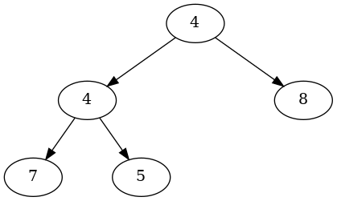

What is the result of inserting 8 into the heap?

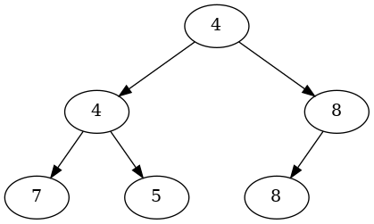

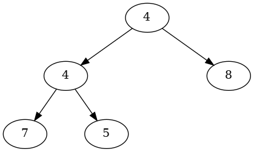

What is the result of inserting 2 into the heap?

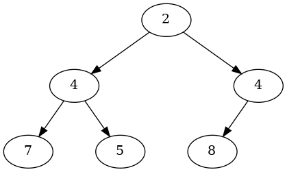

Work with a partner.

What is the result of inserting 4 into this tree.

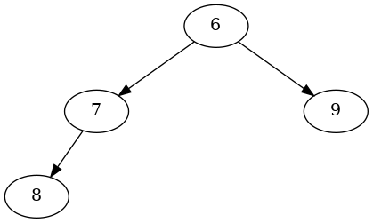

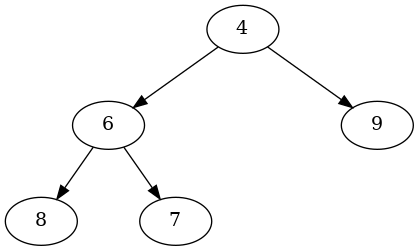

What is the result of inserting 5, 2, 8, 3, 1, 9, 6, 4 into an empty heap?

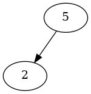

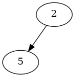

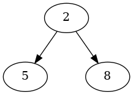

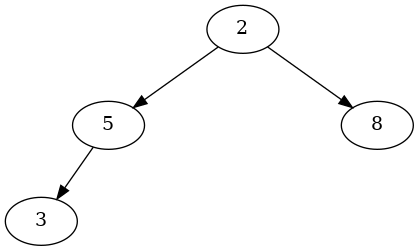

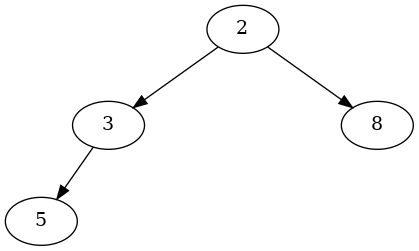

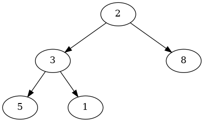

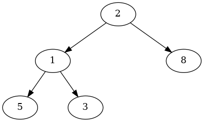

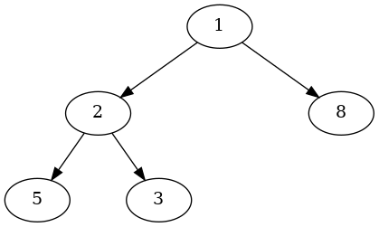

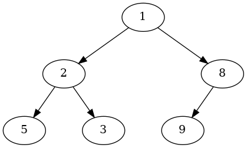

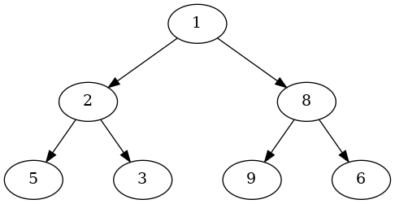

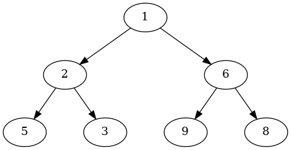

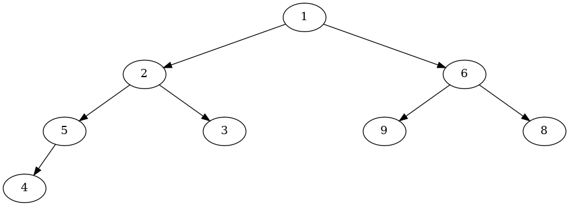

[1 more figures not shown]

You may work with a partner.

Show the result of inserting 5, 3, 8, 1, 7, 4, 6, 2 into an empty Heap.

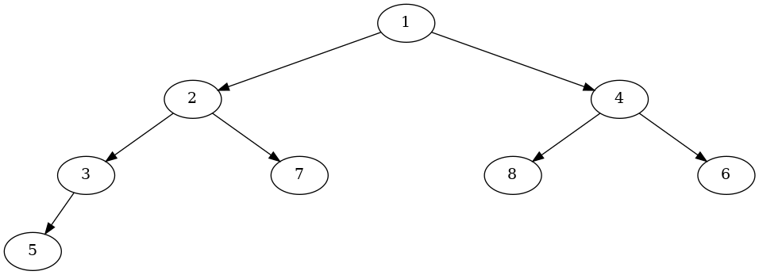

## Big-O

- What is the big-O for inserting into a heap?

$O(\log n)$ for worst case.

$O(1)$ for average case.

Intuition: https://stackoverflow.com/a/39517553/2288986

- Half of the items are leaves, and leaves are heavy, and non-leaves are light.
- The inserted item has a $\frac{1}{2}$ chance of staying put as a leaf.
- It has a $\left(\frac{1}{2}\right)^2 = \frac{1}{4}$ chance of ending up in the $height=1$ row.
- Thus, the probability of taking another step decreases exponentially.
- The result is an average of $O(1)$ time (actual constant is somewhere near 2).

## Removing from a heap

To remove an item:

- Replace the top with the last item
- Percolate down until the order is correct

To percolate down:

- Compare an item with its **smaller** child
- Swap if the item is larger

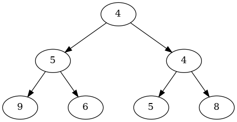

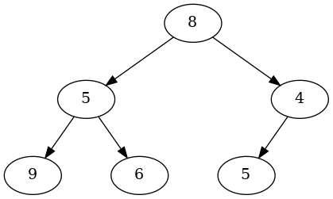

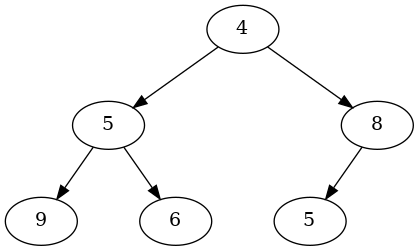

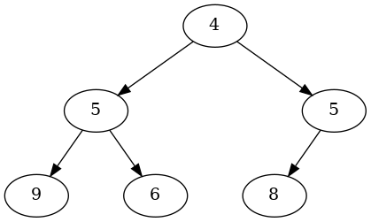

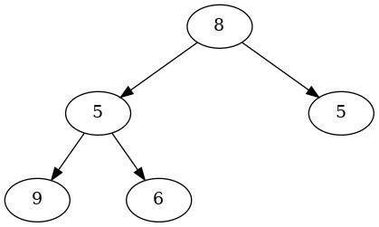

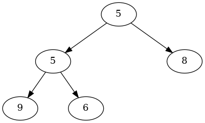

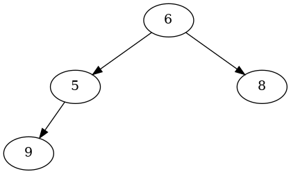

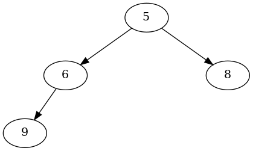

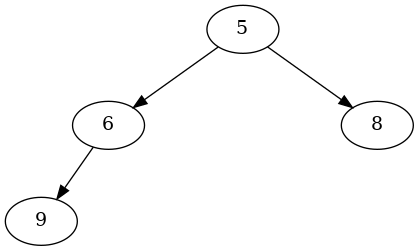

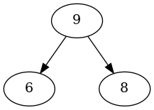

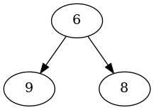

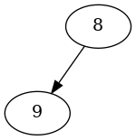

Work with a partner.

Show all the steps of removing an item from the heap.

**Remember**, you can only remove the top element.

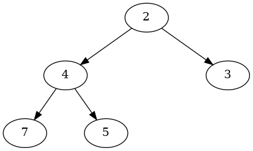

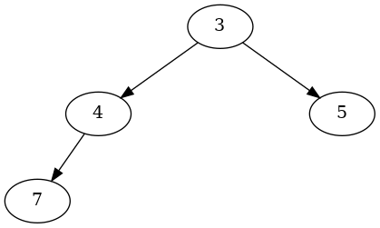

## Big-O

- What is the big-O for removing from a heap?

$O(\log n)$ for both average and worst case.

## Implementing a Heap

Observe:

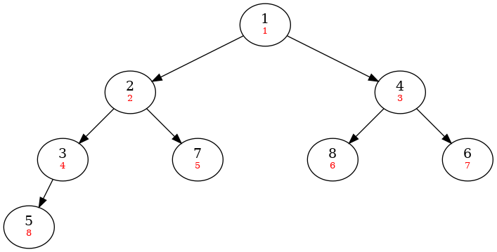

Let's call the red numbers the "index" of the node.

What is the relationship between the index of the parent and the index of the **left** child?

What is the relationship between the index of the **left** child and the index of the **right** child?

What do all left children have in common? What do all right children have in common?

Inasmuch as a heap is a **complete** tree, items are only added or removed **from the end**.

Each item in the tree has an index, and the index of a node can be calculated from the index of a parent or child.

So, we typically implement a heap using an array!

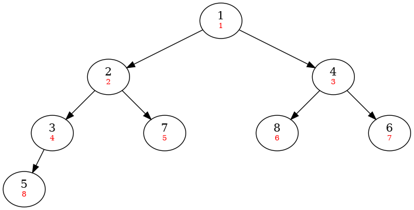

```
value: 1 2 4 3 7 8 6 5
index: 1 2 3 4 5 6 7 8
```

How do you find the children of a node?

Left: $2i$  
Right: $2i+1$

How do you find the parent of a node?

$i/2$

So, given the heap

```
1 2 4 3 7 8 6 5
```

what is the result of inserting a 2?

```
value:  1 2 4 3 7 8 6 5 2
index:  1 2 3 4 5 6 7 8 9

i = 9
p = 9/2 = 4
value[4] = 3
3 > 2, so swap

value:  1 2 4 2 7 8 6 5 3
index:  1 2 3 4 5 6 7 8 9

i = 4
p = 4 / 2 = 2
value[2] = 2
2 !> 2, so done.


1 2 4 2 7 8 6 5 3
```

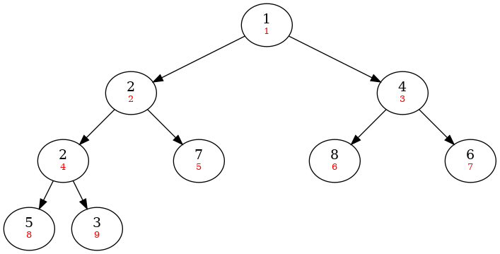

```
1 2 4 2 7 8 6 5 3
```

What is the result of removing an item from this heap?

```
3 4 3 5 4 6 8 5 8
```

```
value:  3 4 3 5 4 6 8 5 8
index:  1 2 3 4 5 6 7 8 9


value:  8 4 3 5 4 6 8 5
index:  1 2 3 4 5 6 7 8 9

i = 1
left = 2*1 = 2
right = left + 1 = 3
value[2] = 4
value[3] = 3
3 is smaller, so use child=3
8 > 3, so swap

value:  3 4 8 5 4 6 8 5
index:  1 2 3 4 5 6 7 8 9

i = 3
left = 6
right = 7
value[6] = 6
value[7] = 8
6 is smaller, so use child=6
8 > 6, so swap

value:  3 4 6 5 4 8 8 5
index:  1 2 3 4 5 6 7 8 9

i = 6
left = 12 (no child)
right = 13 (no child)
done.
```

**Note**: when using actual arrays, we need to use 0-based indexing.

#### 0-based Heap Relationships

- Root is at 0
- Left child is at $2i+1$
- Right child is at $2i+2$
- Parent is at $\frac{i-1}{2}$

## Key Ideas

What data structure only allows you to retrieve the smallest item, regardless of the order you insert them?

A **priority queue**!

Priority queues are implemented using heaps.